# Stock Market Prediction

Author

Jia Xin Tang Zhi

# Project :

*Regression task*, where we want to predict stock returns from panel-type data (last columnn).

## Import library

```r
#install.packages("tidyverse")
#install.packages("psych")
#install.packages("lightgbm")
#install.packages("iml")
```

# Data wrangling

First, let’s load the data & the packages.

```r
library(tidyverse)
library(dplyr)              # for data manipulation
library(ggplot2)            # For the plots
library(gridExtra)          # to arrange 2 graphs in one row
library(psych)              # for comprehensive summary
library(rlang)              # for in-built functions
library(forecast)           # for forecasting future values
library(lightgbm)           #for the model lightgbm
```

Let’s load the dataset that comes in RData format.

```r
load('stocks_clean.RData')  # loading the RData file
return <- stocks_clean      # and assigning it to a variable  Return
rm(stocks_clean)            # now that return is assigned, remove remove returns to save memory
```

```r
dim(return)   # Dimension of the dataframe
```

```
[1] 289271     13
```

```r
head(return)  # Look at the first and last observations of the dataframe
```

| ticker | date | price | market_cap | price_to_book | debt_to_equity | profitability | volatility | revenue | ghg_s1 | ghg_s2 | ghg_s3 | return |
| --- | --- | --- | --- | --- | --- | --- | --- | --- | --- | --- | --- | --- |
| AAON US Equity | 1995-12-31 | 0.5048 | 35.1440 | 2.5948 | 85.9073 | 0.8628 | 71.728 | 14.720 | NA | NA | NA | -0.0980883 |
| AAON US Equity | 1996-01-31 | 0.4719 | 32.8520 | 2.4256 | 85.9073 | 3.0722 | 63.087 | 67.346 | NA | NA | NA | -0.0651743 |
| AAON US Equity | 1996-02-29 | 0.5048 | 35.1440 | 2.5948 | 85.9073 | 3.0722 | 97.639 | 67.346 | NA | NA | NA | 0.0697182 |
| AAON US Equity | 1996-03-31 | 0.4170 | 29.0367 | 2.0805 | 65.1878 | 3.1180 | 100.450 | 13.438 | NA | NA | NA | -0.1739303 |
| AAON US Equity | 1996-04-30 | 0.3841 | 26.7444 | 1.9162 | 65.1878 | 3.1180 | 76.133 | 13.438 | NA | NA | NA | -0.0788969 |
| AAON US Equity | 1996-05-31 | 0.3951 | 27.5445 | 1.9710 | 65.1878 | 3.1180 | 88.304 | 13.438 | NA | NA | NA | 0.0286384 |

```r
tail(return)
```

| ticker | date | price | market_cap | price_to_book | debt_to_equity | profitability | volatility | revenue | ghg_s1 | ghg_s2 | ghg_s3 | return |
| --- | --- | --- | --- | --- | --- | --- | --- | --- | --- | --- | --- | --- |
| ZIXI US Equity | 2022-07-29 | 8.485 | 481.8671 | 14.1059 | 146.8623 | -3.7101 | 4.118 | 64.85 | NA | NA | NA | 0 |
| ZIXI US Equity | 2022-08-31 | 8.485 | 481.8671 | 14.1059 | 146.8623 | -3.7101 | 4.118 | 64.85 | NA | NA | NA | 0 |
| ZIXI US Equity | 2022-09-30 | 8.485 | 481.8671 | 14.1059 | NA | NA | 4.118 | NA | NA | NA | NA | 0 |
| ZIXI US Equity | 2022-10-31 | 8.485 | 481.8671 | 14.1059 | NA | NA | 4.118 | NA | NA | NA | NA | 0 |
| ZIXI US Equity | 2022-11-30 | 8.485 | 481.8671 | 14.1059 | NA | NA | 4.118 | NA | NA | NA | NA | 0 |
| ZIXI US Equity | 2022-12-30 | 8.485 | 481.8671 | 14.1059 | NA | NA | 4.118 | NA | NA | NA | NA | 0 |

We can see that there are 289271 observations (rows) and 13 variables (features) so the dataset is quite large. - The last variable called **“return”** is the target variable amd well positioned at the last column.

## Structure and statistics of the dataset

### Structure

```r
str(return[,1:13])    # Provides the structure , datatype
```

```
tibble [289,271 × 13] (S3: tbl_df/tbl/data.frame)
 $ ticker        : chr [1:289271] "AAON US Equity" "AAON US Equity" "AAON US Equity" "AAON US Equity" ...
 $ date          : Date[1:289271], format: "1995-12-31" "1996-01-31" ...
 $ price         : num [1:289271] 0.505 0.472 0.505 0.417 0.384 ...
 $ market_cap    : num [1:289271] 35.1 32.9 35.1 29 26.7 ...
 $ price_to_book : num [1:289271] 2.59 2.43 2.59 2.08 1.92 ...
 $ debt_to_equity: num [1:289271] 85.9 85.9 85.9 65.2 65.2 ...
 $ profitability : num [1:289271] 0.863 3.072 3.072 3.118 3.118 ...
 $ volatility    : num [1:289271] 71.7 63.1 97.6 100.5 76.1 ...
 $ revenue       : num [1:289271] 14.7 67.3 67.3 13.4 13.4 ...
 $ ghg_s1        : num [1:289271] NA NA NA NA NA NA NA NA NA NA ...
 $ ghg_s2        : num [1:289271] NA NA NA NA NA NA NA NA NA NA ...
 $ ghg_s3        : num [1:289271] NA NA NA NA NA NA NA NA NA NA ...
 $ return        : num [1:289271] -0.0981 -0.0652 0.0697 -0.1739 -0.0789 ...
```

There seems to be character, Date and numerical type of data. Let’s have a precise view using the module class.

```r
sapply(return, class) |> table() |> head()
```

```
character      Date   numeric
        1         1        11
```

### Statistics

```r
statistics <- summary(return) #provides a summary of statistics for numerical values
statistics_df <- as.data.frame(statistics) #creating a dataframe for better view assigning to a vector statistics_df

# Then use the describe function
describe_stats <- describe(statistics_df)
describe_stats
```

|  | vars | n | mean | sd | median | trimmed | mad | min | max | range | skew | kurtosis | se |
| --- | --- | --- | --- | --- | --- | --- | --- | --- | --- | --- | --- | --- | --- |
| Var1* | 1 | 91 | 1.00000 | 0.000000 | 1.0 | 1.00000 | 0.0000 | 1 | 1 | 0 | NaN | NaN | 0.0000000 |
| Var2* | 2 | 91 | 7.00000 | 3.762387 | 7.0 | 7.00000 | 4.4478 | 1 | 13 | 12 | 0.0000000 | -1.253316 | 0.3944053 |
| Freq* | 3 | 84 | 41.82143 | 23.494763 | 42.5 | 42.01471 | 30.3933 | 1 | 81 | 80 | -0.0697899 | -1.261956 | 2.5634888 |

```r
summary(return$return)  # descriptive summary of the predictive variable
```

```
     Min.   1st Qu.    Median      Mean   3rd Qu.      Max.
-0.999900 -0.046077  0.007165  0.011707  0.061672  4.140351
```

```r
psych::describe(return)  # more details
```

|  | vars | n | mean | sd | median | trimmed | mad | min | max | range | skew | kurtosis | se |
| --- | --- | --- | --- | --- | --- | --- | --- | --- | --- | --- | --- | --- | --- |
| ticker* | 1 | 289271 | 442.8751862 | 2.554853e+02 | 443.0000000 | 442.8453398 | 327.6546000 | 1.0000e+00 | 8.850000e+02 | 8.840000e+02 | -0.0003507 | -1.198849 | 0.4750218 |
| date | 2 | 289271 | NaN | NA | NA | NaN | NA | Inf | -Inf | -Inf | NA | NA | NA |
| price | 3 | 289271 | 47.5231056 | 1.358301e+02 | 24.6000000 | 29.2883421 | 21.9721320 | 1.0000e-06 | 5.908870e+03 | 5.908870e+03 | 18.4437518 | 485.375142 | 0.2525477 |
| market_cap | 4 | 285271 | 14358.8671009 | 5.284050e+04 | 1783.9113000 | 4689.8198910 | 2431.9996634 | 1.2000e-02 | 2.913284e+06 | 2.913284e+06 | 20.4232946 | 762.572413 | 98.9322942 |
| price_to_book | 5 | 269118 | 6.9235647 | 3.650293e+02 | 2.0421000 | 2.3796616 | 1.3192175 | 4.0000e-04 | 1.239516e+05 | 1.239516e+05 | 292.0519380 | 88943.404460 | 0.7036495 |
| debt_to_equity | 6 | 279183 | 202.9767215 | 4.641365e+03 | 52.8601000 | 63.9115311 | 60.8140281 | 0.0000e+00 | 1.188137e+06 | 1.188137e+06 | 187.9389783 | 46359.668753 | 8.7841811 |
| profitability | 7 | 283169 | -238.4942549 | 2.270789e+04 | 7.3622000 | 8.8191991 | 8.0604514 | -3.3007e+06 | 3.703000e+05 | 3.671000e+06 | -133.5345377 | 18751.861019 | 42.6730831 |
| volatility | 8 | 289084 | 39.1337053 | 3.991481e+01 | 30.7070000 | 33.5309748 | 15.8830938 | 0.0000e+00 | 5.137323e+03 | 5.137323e+03 | 29.3463638 | 2549.313940 | 0.0742373 |
| revenue | 9 | 284166 | 19533.5954801 | 4.259334e+05 | 443.5000000 | 1153.5807626 | 611.3115624 | -2.7966e+04 | 3.137951e+07 | 3.140747e+07 | 40.9380333 | 2104.805636 | 799.0163901 |
| ghg_s1 | 10 | 37575 | 5209.6830526 | 1.565725e+04 | 212.1960000 | 1376.6898118 | 305.4215304 | 0.0000e+00 | 1.455000e+05 | 1.455000e+05 | 5.0702658 | 30.350285 | 80.7729651 |
| ghg_s2 | 11 | 35717 | 1138.8577400 | 2.507859e+03 | 279.6060000 | 534.8833402 | 373.5054876 | 0.0000e+00 | 2.900000e+04 | 2.900000e+04 | 4.6730604 | 28.919859 | 13.2698360 |
| ghg_s3 | 12 | 24404 | 30353.2335338 | 1.028987e+05 | 549.5130000 | 5531.2176450 | 805.1718906 | 0.0000e+00 | 1.169970e+06 | 1.169970e+06 | 5.0776069 | 29.746759 | 658.6875273 |
| return | 13 | 289271 | 0.0117065 | 1.241597e-01 | 0.0071651 | 0.0079437 | 0.0798772 | -9.9990e-01 | 4.140351e+00 | 5.140251e+00 | 3.2588582 | 61.246547 | 0.0002308 |

```r
# Calculate missing values
sapply(return, function(x) sum(is.na(x)))
```

```
        ticker           date          price     market_cap  price_to_book
             0              0              0           4000          20153
debt_to_equity  profitability     volatility        revenue         ghg_s1
         10088           6102            187           5105         251696
        ghg_s2         ghg_s3         return
        253554         264867              0
```

```r
# Calculate the threshold for missing values
threshold <- nrow(return) * 0.85

# Remove columns where the number of missing values is greater than the threshold
return <- return |>
  select_if(~sum(is.na(.)) < threshold)

# Replace NA values with the mean of each column with missing values
return <- return |>
  mutate(market_cap = ifelse(is.na(market_cap), mean(market_cap, na.rm = TRUE), market_cap),
         price_to_book = ifelse(is.na(price_to_book), mean(price_to_book, na.rm = TRUE), price_to_book),
         debt_to_equity = ifelse(is.na(debt_to_equity), mean(debt_to_equity, na.rm = TRUE), debt_to_equity),
         profitability = ifelse(is.na(profitability), mean(profitability, na.rm = TRUE), profitability),
         volatility = ifelse(is.na(volatility), mean(volatility, na.rm = TRUE), volatility),
         revenue = ifelse(is.na(revenue), mean(revenue, na.rm = TRUE), revenue))

sapply(return, function(x) sum(is.na(x)))
```

```
        ticker           date          price     market_cap  price_to_book
             0              0              0              0              0
debt_to_equity  profitability     volatility        revenue         return
             0              0              0              0              0
```

## Uni-variate Analysis

### Categorical Values

```r
# Aggregated market_cap by ticker
aggregated_data <- return |>
  group_by(ticker) |>
  summarise(total_market_cap = sum(market_cap, na.rm = TRUE))
```

```r
# Filter for the top 20 tickers by market cap
top_n <- 20
aggregated_data_top_n <- aggregated_data |>
  top_n(n = top_n, wt = total_market_cap)
```

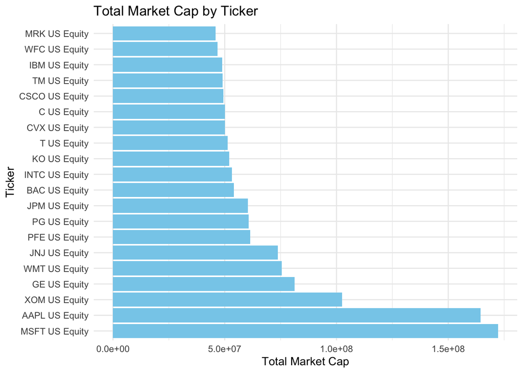

```r
# Plot only the top N tickers
ggplot(aggregated_data_top_n, aes(x = reorder(ticker, -total_market_cap), y = total_market_cap)) +
  geom_bar(stat = "identity", fill = "skyblue") +
  theme_minimal() +
  labs(title = "Total Market Cap by Ticker", x = "Ticker", y = "Total Market Cap") +
  coord_flip() # Flip coordinates for horizontal bars
```

For positive variables, when tails are very heavy, use the +scale_x_log10() layer for histograms :

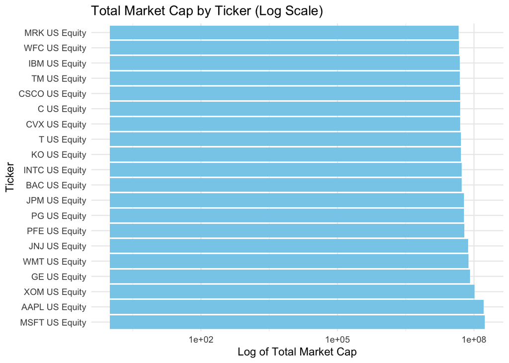

```r
# Plot only the top N tickers with log-transformed y-axis
ggplot(aggregated_data_top_n, aes(x = reorder(ticker, -total_market_cap), y = total_market_cap)) +
  geom_bar(stat = "identity", fill = "skyblue") +
  scale_y_log10() + # Log-transform the y-axis
  theme_minimal() +
  labs(title = "Total Market Cap by Ticker (Log Scale)", x = "Ticker", y = "Log of Total Market Cap") +
  coord_flip() # Flip coordinates for horizontal bars
```

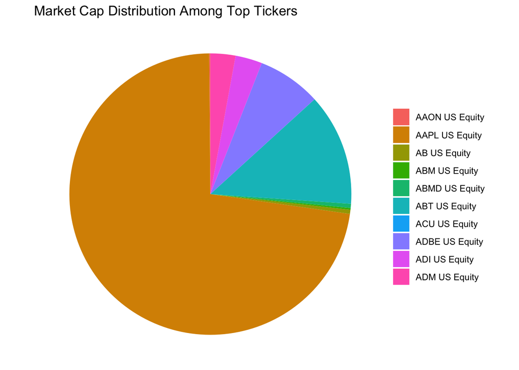

```r
# Using the first 10 tickers to analyse
top_tickers_data <- head(aggregated_data, 10)

# Creating a pie chart
ggplot(top_tickers_data, aes(x = "", y = total_market_cap, fill = ticker)) +
  geom_bar(width = 1, stat = "identity") +
  coord_polar("y") + # Convert the bar chart to a pie chart
  theme_void() + # Remove background and axes
  labs(title = "Market Cap Distribution Among Top Tickers") +
  theme(legend.title = element_blank()) # Hide the legend title
```

### Numerical Values

```r
plot_histogram_boxplot <- function(data, var_name) {
  # Convert the variable name to a symbol for ggplot
  var <- sym(var_name)

  # Create a histogram plot
  p1 <- ggplot(data, aes(x = !!var)) +
    geom_histogram(bins = 30, fill = "skyblue", color = "black") +
    theme_minimal() +
    labs(title = paste("Histogram of", var_name), x = var_name, y = "Count")

  # Create a boxplot
  p2 <- ggplot(data, aes(x = "", y = !!var)) +
    geom_boxplot(fill = "tomato", color = "black") +
    theme_minimal() +
    labs(title = paste("Boxplot of", var_name), x = "", y = var_name)

  # Combine plots using grid.arrange
  grid.arrange(p1, p2, ncol = 2)
}
```

```
[1] "Plotting for: price"
```

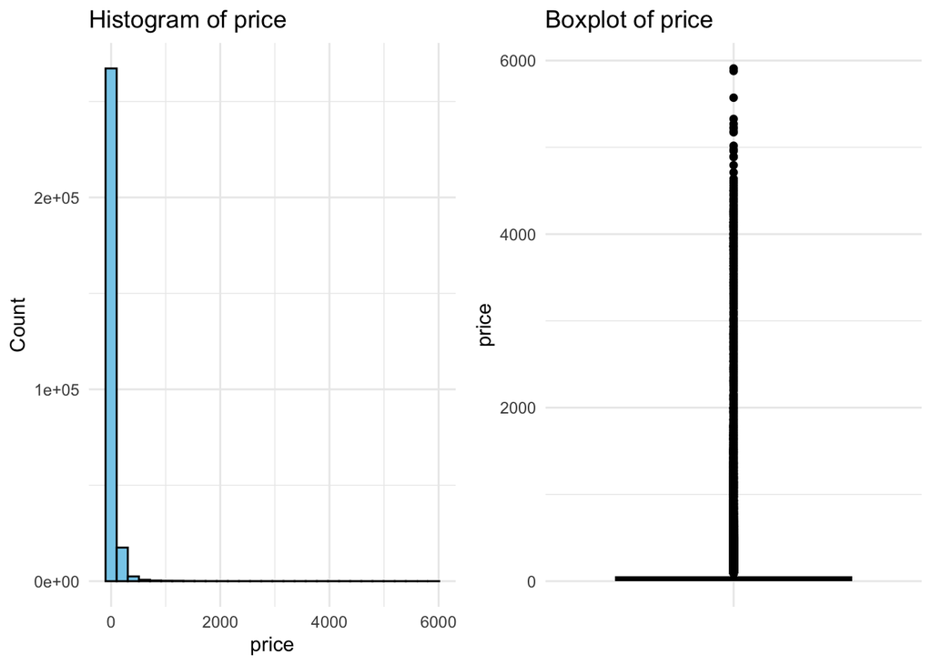

```
[1] "Plotting for: market_cap"
```

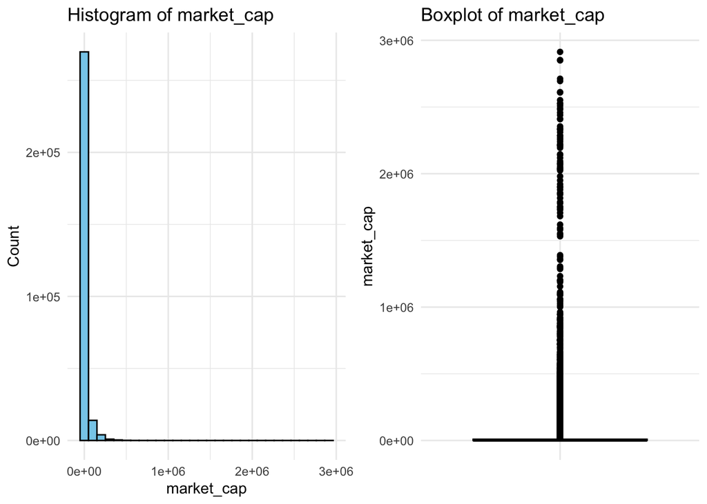

```
[1] "Plotting for: price_to_book"
```

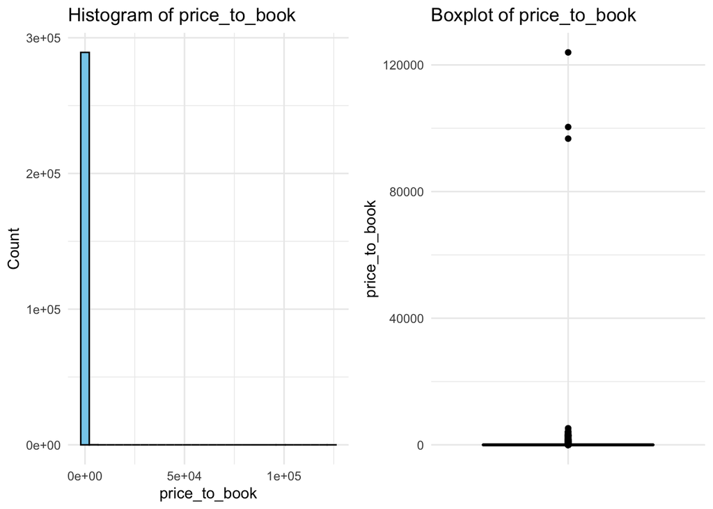

```
[1] "Plotting for: debt_to_equity"
```

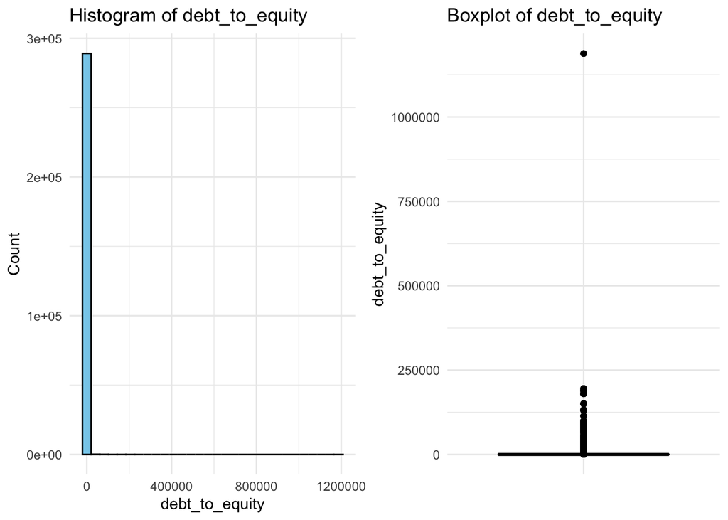

```
[1] "Plotting for: profitability"
```

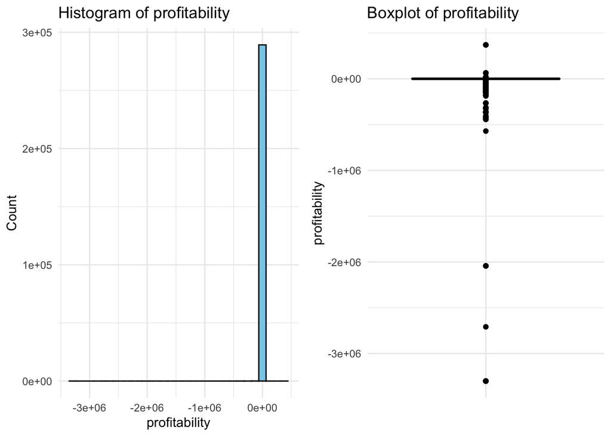

```
[1] "Plotting for: volatility"
```

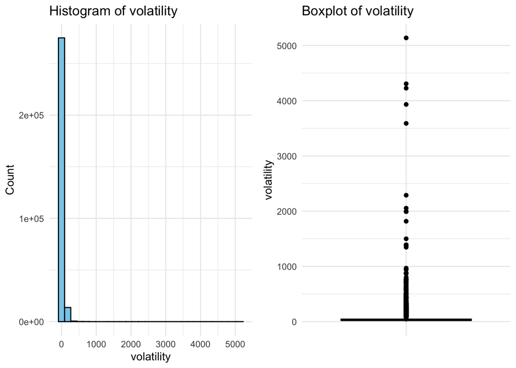

```
[1] "Plotting for: revenue"
```

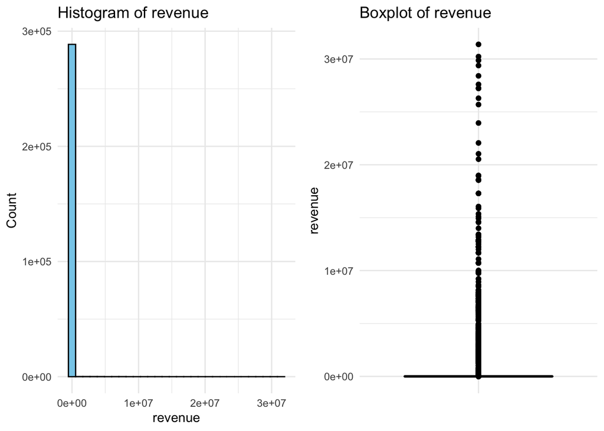

```
[1] "Plotting for: return"
```

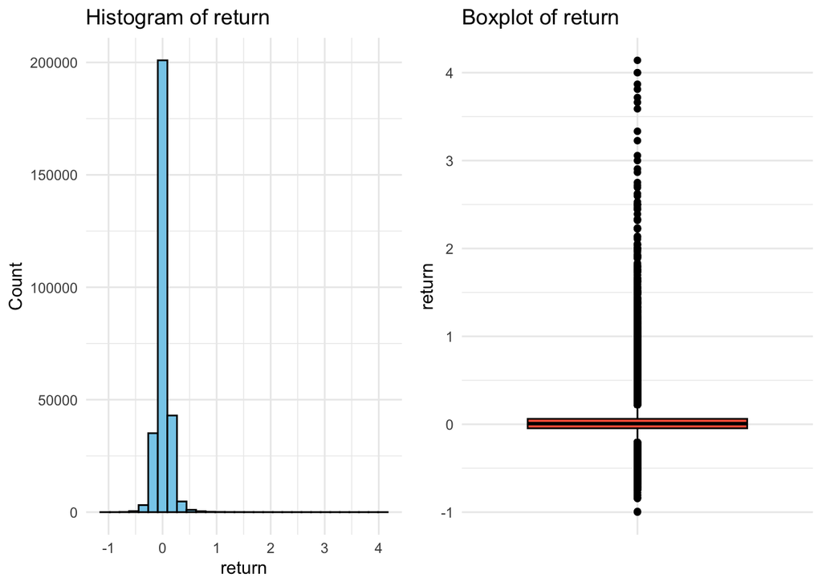

```r
# List of quantitative variable names to plot
quantitative_vars <- c("price", "market_cap", "price_to_book", "debt_to_equity",
                       "profitability", "volatility", "revenue", "return")

# Loop through each variable and plot
for(var_name in quantitative_vars) {
  print(paste("Plotting for:", var_name)) # Print the variable name being plotted
  plot_histogram_boxplot(return, var_name)
}
```

# Modeling using ARIMA

ARIMA models are well-suited for time series data that show patterns over time and can be made stationary through differentiation. It is useful for forecasting future points in a series based on its own past values (autoregression) and a moving average of past errors. * Use case for VARIMA: If the `return` variable shows autocorrelation over time (which means past returns are predictive of future returns)

Due to the large amount stocks, we will explore some tickets in order to simplify it.

## Example 1 - “AAPL US Equity” ticker

### Data Preprocessing

```r
ticker_name <- "AAPL US Equity"  # Replace with the ticker you want to predict

# Filter the data for the selected ticker
ticker_data <- return |> filter(ticker == ticker_name)

# Order the data by date
ticker_data <- ticker_data |> arrange(date)
```

### Split the Data

```r
# Calculate the splitting index
split_index <- floor(0.8 * nrow(ticker_data))

# Create training and testing datasets
train_data <- ticker_data[1:split_index, ]
test_data <- ticker_data[(split_index + 1):nrow(ticker_data), ]
```

```r
# Fit an ARIMA model
return_arima <- auto.arima(train_data$return)
summary(return_arima)
```

```
Series: train_data$return
ARIMA(1,0,1) with non-zero mean

Coefficients:
         ar1      ma1    mean
      0.6134  -0.5783  0.0265
s.e.  1.1523   1.1973  0.0085

sigma^2 = 0.01625:  log likelihood = 169.39
AIC=-330.77   AICc=-330.62   BIC=-316.5

Training set error measures:
                       ME      RMSE        MAE  MPE MAPE      MASE         ACF1
Training set 0.0001031105 0.1267608 0.09507222 -Inf  Inf 0.7166279 0.0004694282
```

### Predicting Future Returns

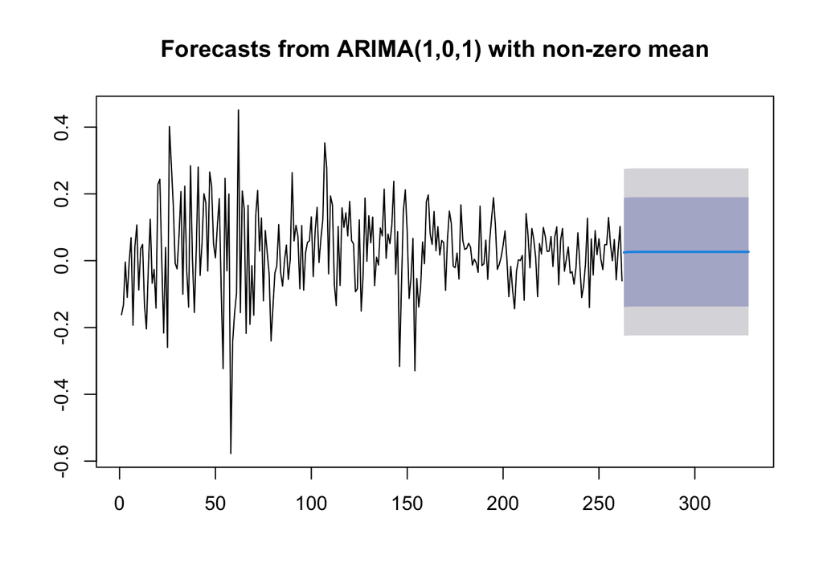

```r
# Make predictions
predictions <- forecast(return_arima, h = nrow(test_data))  # 'h' is the number of periods to predict

# Plot the predictions against the actual test data
plot(predictions)
lines(test_data$date, test_data$return, col = "red")
```

The blue line in the graph likely represents the forecasted values generated by the ARIMA model for the specified future periods (as defined by `h = nrow(test_data)`). It is the model’s best estimate of the time series’ central tendency moving forward.

Representation :

- **Black Line* : This is the historical time series data upon which the model was trained.
- **Blue Line** : This line is the point forecast from the ARIMA model, indicating the expected value of the series at each future point.
- **Grey Shaded Area** : This usually depicts the prediction intervals (often 80% and 95% confidence intervals) around the point forecasts, representing the uncertainty in the forecasts. The lighter the shade of grey, the lower the confidence (i.e., the wider the interval).

In the graph, the blue line shows where the model predicts the return will be, on average, for the next h periods. The shaded area around it indicates the level of confidence the model has in its predictions; the actual future values are expected to fall within this range most of the time, given the model assumptions hold true.

The range of 0 to 300 on the x-axis of your ARIMA forecast plot represents the index of the observations in the time series data. This is a common default in time series plots when the time series object doesn’t have an associated time/date attribute or when the plotting function isn’t explicitly told to use a date variable for the x-axis. While the y-axis, labeled `return`, represents the values of the variable being forecast by the ARIMA(1,0,1) model

### Performance Evaluation

```r
# Calculate accuracy metrics
accuracy(predictions, test_data$return)
```

```
                        ME       RMSE        MAE      MPE     MAPE      MASE
Training set  0.0001031105 0.12676080 0.09507222     -Inf      Inf 0.7166279
Test set     -0.0001558202 0.09022325 0.07685722 114.7769 124.9835 0.5793283
                     ACF1
Training set 0.0004694282
Test set               NA
```

In the evaluation, *-Inf* and *Inf* values for **MPE** and **MAPE** suggest that there are cases where actual values are zero or very close to zero. In such cases, these percentage errors can become infinite or undefined, which is why they are not good measures for rendering these metrics unsuitable for this dataset.

The **RMSE** value of *0.0902* for the test set indicates that the forecast errors are moderate, and ideally, we would look for a lower RMSE for better forecast accuracy. The **MAE** is measured at *0.0769* for the test set, which similarly points to moderate errors; as with RMSE, a lower MAE would mean the predictions are closer to the actual values. The **MASE** stands at *0.579* for the test set, which is less than 1, suggesting that the forecasting model is performing better than a naive benchmark model.

## Example 2 - “ZIXI US Equity” ticker

### Data Preprocessing

```r
ticker_name <- "ZIXI US Equity"  # Replace with the ticker you want to predict

# Filter the data for the selected ticker
ticker_data <- return |> filter(ticker == ticker_name)

# Order the data by date
ticker_data <- ticker_data |> arrange(date)
```

### Split the Data

```r
# Calculate the splitting index
split_index <- floor(0.8 * nrow(ticker_data))

# Create training and testing datasets
train_data <- ticker_data[1:split_index, ]
test_data <- ticker_data[(split_index + 1):nrow(ticker_data), ]
```

```r
# Fit an ARIMA model
return_arima <- auto.arima(train_data$return)
summary(return_arima)
```

```
Series: train_data$return
ARIMA(0,0,0) with non-zero mean

Coefficients:
        mean
      0.0278
s.e.  0.0162

sigma^2 = 0.06814:  log likelihood = -19.22
AIC=42.44   AICc=42.49   BIC=49.56

Training set error measures:
                       ME     RMSE       MAE  MPE MAPE      MASE          ACF1
Training set 3.956344e-14 0.260537 0.1697435 -Inf  Inf 0.6678411 -0.0007031951
```

### Predicting Future Returns

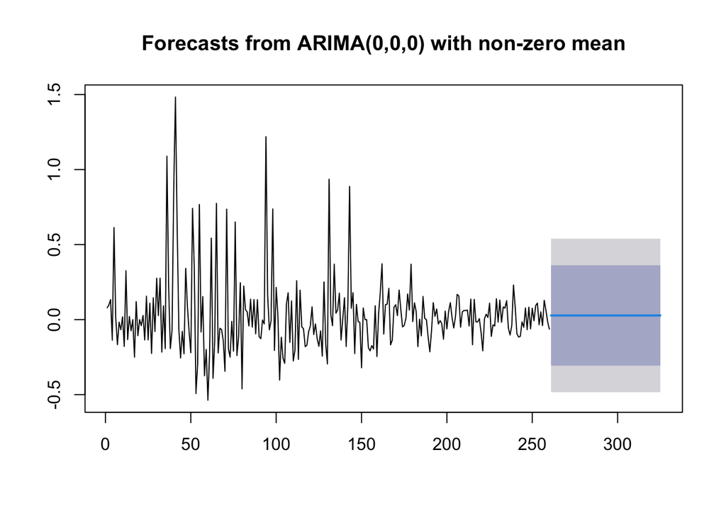

```r
# Make predictions
predictions <- forecast(return_arima, h = nrow(test_data))  # 'h' is the number of periods to predict

# Plot the predictions against the actual test data
plot(predictions)
lines(test_data$date, test_data$return, col = "red")
```

### Performance Evaluation

```r
# Calculate accuracy metrics
accuracy(predictions, test_data$return)
```

```
                        ME      RMSE        MAE  MPE MAPE      MASE
Training set  3.956344e-14 0.2605370 0.16974349 -Inf  Inf 0.6678411
Test set     -1.277648e-02 0.1217997 0.08573132 -Inf  Inf 0.3373024
                      ACF1
Training set -0.0007031951
Test set                NA
```

The **RMSE** on the test set is *0.122*, which gives you an idea about the typical size of the forecast errors. The **MASE** being less than one (*0.337*) indicates that the model is performing better than a naive model for the test data set.

# Modeling using lightGBM

## Data Splitting

In this section, we fit a boosted tree from the lightGBM package. We split the data in two, for simplicity: we won’t use **validation**.

```r
# Setting seed for reproducibility
set.seed(123)

# Data preparation
train_indices <- sample(1:nrow(return), 0.8 * nrow(return))  # 80% for training
train_data <- return[train_indices, ]
remaining_indices <- setdiff(1:nrow(return), train_indices)  # Indices not in training set

# Test set
test_size <- 0.2  # 20% for testing
test_indices <- sample(remaining_indices, test_size * length(remaining_indices))
test_data <- return[test_indices, ]

# Future validation set
remaining_indices <- setdiff(remaining_indices, test_indices)  # Remove test indices
validation_indices <- sample(remaining_indices, 0.2 * length(remaining_indices))  # 20% of remaining data for validation
validation_data <- return[validation_indices, -which(names(return) == "return")]  # Remove 'return' column
```

```r
# Convert data to LightGBM format
train_data_lgb <- lgb.Dataset(data = as.matrix(train_data[, -which(names(train_data) == "return")]), label = train_data$return)
test_data_lgb <- lgb.Dataset(data = as.matrix(test_data[, -1]), label = test_data$return, reference = train_data_lgb)
# Define LightGBM parameters
train_params <- list(
  objective = "regression",  # Regression task
  metric = "rmse",  # Root Mean Square Error as the evaluation metric
  num_leaves = 31,  # Maximum number of leaves in one tree
  learning_rate = 0.1,  # Learning rate
  feature_fraction = 0.8,  # Percentage of features used per iteration
  bagging_fraction = 0.8,  # Percentage of data used per iteration
  bagging_freq = 5,  # Frequency for bagging
  verbose = -1  # No print updates
)
```

## Training

```r
lgb_model <- lgb.train(params = train_params,
                       data = train_data_lgb,
                       nrounds = 100,  # Number of boosting iterations (trees)
                       valids = list(validation = test_data_lgb),
                       early_stopping_rounds = 10)  # Early stopping
```

## Prediction & evaluation

```r
predictions <- predict(lgb_model, newdata = as.matrix(test_data[, -1]))
rmse <- sqrt(mean((predictions - test_data$return)^2))
cat("RMSE:", rmse, "\n")
```

```
RMSE: 0.1255344
```

```r
mae <- mean(abs(predictions - test_data$return))
cat("MAE:", mae, "\n")
```

```
MAE: 0.08153906
```

We obtained a 8% of error for returns, which is not negligible, with a **MAE** of *0.082*, & **RMSE** of *0.126*.

# Interpretability

In the realm of finance, where money management is pivotal, there is a significant preference for transparent algorithms that support decision-making. Stakeholders demand to understand the underlying reasoning of predictive models, which leads to the crucial distinction between global and local interpretability.

Global interpretability allows us to comprehend the model’s mechanisms over the aggregate data, offering insights on how the model makes decisions across the broad spectrum of data. An exemplar of this is the lightGBM model we trained, whose feature importance chart, displaying the aggregated gains across the ensemble of trees, exemplifies global interpretability. Such clarity is not just academic but practical, allowing for refined models that prioritize transparency in their predictive logic.

## Feature Importance

Feature importance can help in understanding the model’s decision-making process and in the reduction of the feature space for more efficient models.

```r
lgb_importance <- lgb.importance(model = lgb_model, percentage = TRUE)
print(lgb_importance)
```

```
          Feature       Gain        Cover Frequency
           <char>      <num>        <num>     <num>
1:     volatility 0.32614683 0.4703797605 0.2000000
2:  price_to_book 0.25451039 0.4439211563 0.2000000
3:     market_cap 0.18233986 0.0500271586 0.2666667
4:          price 0.10241046 0.0008298006 0.1000000
5:        revenue 0.08431652 0.0343258741 0.1333333
6: debt_to_equity 0.05027594 0.0005162500 0.1000000
```

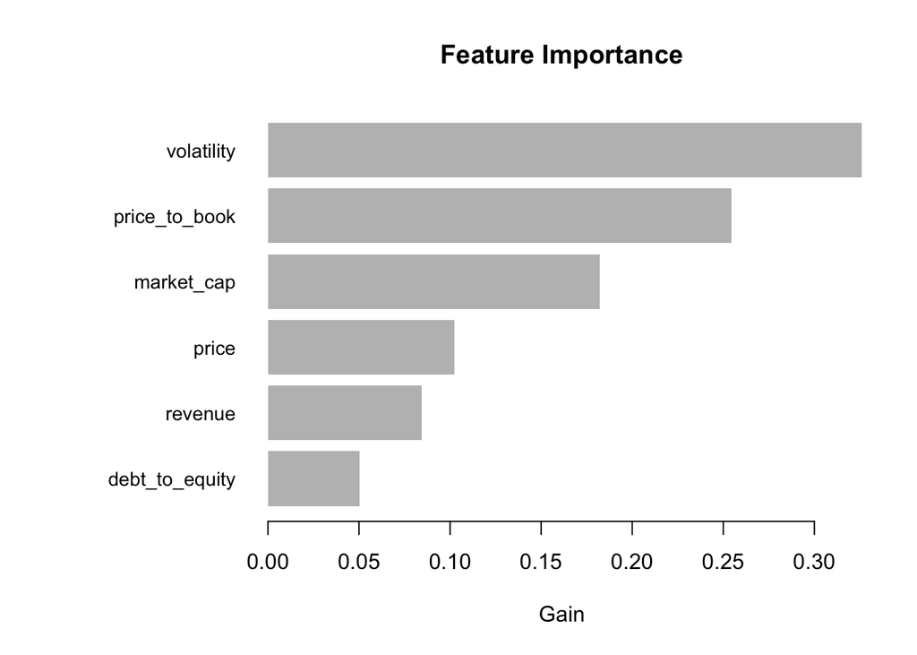

```r
lgb.plot.importance(lgb_importance)
```

**volatility** seems to be the most important feature, contributing the most to the model’s predictions, followed by **price_to_book** and **market_cap**. The features **price**, **revenue**, and **debt_to_equity** have lower importance scores in this model.